# Assignment 6

This assignment has weighting $3.5$. The first question about clustering has 35%, and the second question about tiny image classification has 65%.

This is a challenging assignment, so I recommend you start early.

# Clustering for handwritten digits

Supervised learning requires labeled data, which can be expensive to acquire. For example, a dataset with $N$ samples for classification will require manual labeling $N$ times.

One way to ameliorate this issue is to perform clustering of the raw data samples first, followed by manual inspection and labeling of only a few samples. Recall that clustering is a form of non-supervised learning, so it does not require any class labels.

For example, say we are given a set of scanned hand-written digit images. We can cluster them into 10 groups first, manually inspect and label a few images in each cluster, and propagate the label towards the rest of all (unlabeled) samples in each cluster.

The accuracy of such semi-automatic labeling depends on the accuracy of the clustering. If each cluster (0 to 9) corresponds exactly to hand-written digits 0-9, we are fine. Otherwise, we have some mis-labeled data.

The goal of this question is to exercise clustering of the scikit-learn digits dataset which has labels, so that we can verify our clustering accuracy. The specifics are as follows.

You will be judged by the test accuracy of your code, and quality of descriptions of your method. As a reference, a simple code I (Li-Yi) wrote can achieve about 78% accuracy. Try to beat it as much as you can.

## Training and test data split

We will split the original dataset into training and test datasets

- training for building our clusters
- testing to see if the clusters can predict future data

## Accuracy

What is your clustering accuracy (comparing cluster labels with the ground truth labels), and what are the properties of mis-clustered samples?

## Data preprocessing

Would the original features (pixels) work well, or we need further processing like scaling/standardization or dimensionality-reduction, before clustering?

## Models and hyper-parameters

Let's focus on k-means clustering, as hierarchical and density-based clustering do not provide the predict() method under scikit-learn.

What is the best test performance you can achieve with which hyper-parameters (for k-means, standard scalar, and dimensionality reduction)?

### Hint

We have learned Pipeline and GridSearchCV for cross validation and hyper-parameter tuning.

```python
%load_ext watermark
%watermark -a '' -u -d -v -p numpy,pandas,matplotlib,scipy,sklearn
%matplotlib inline
```

```
last updated: 2017-02-01

CPython 3.5.2
IPython 5.1.0

numpy 1.12.0
pandas 0.18.1
matplotlib 1.5.3
scipy 0.18.1
sklearn 0.17.1
```

```python
# Added version check for recent scikit-learn 0.18 checks
from distutils.version import LooseVersion as Version
from sklearn import __version__ as sklearn_version
```

## Load data

```python
import numpy as np

from sklearn.datasets import load_digits
digits = load_digits()

X = digits.data # data in pixels
y = digits.target # digit labels

print(X.shape)
print(y.shape)

print(np.unique(y))
```

```
(1797, 64)
(1797,)
[0 1 2 3 4 5 6 7 8 9]
```

## Visualize data

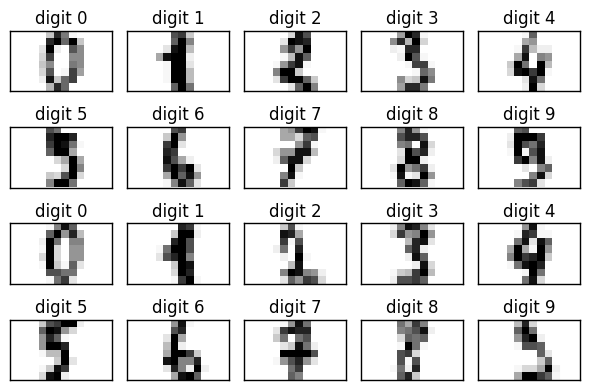

```python
import matplotlib.pyplot as plt
import pylab as pl

num_rows = 4
num_cols = 5

fig, ax = plt.subplots(nrows=num_rows, ncols=num_cols, sharex=True, sharey=True)
ax = ax.flatten()
for index in range(num_rows*num_cols):
    img = digits.images[index]
    label = digits.target[index]
    ax[index].imshow(img, cmap='Greys', interpolation='nearest')
    ax[index].set_title('digit ' + str(label))

ax[0].set_xticks([])
ax[0].set_yticks([])
plt.tight_layout()
plt.show()
```

## Data sets: training versus test

```python
if Version(sklearn_version) < '0.18':
    from sklearn.cross_validation import train_test_split
else:
    from sklearn.model_selection import train_test_split

X_train, X_test, y_train, y_test = train_test_split(
    X, y, test_size=0.3, random_state=1)

num_training = y_train.shape[0]
num_test = y_test.shape[0]
print('training: ' + str(num_training) + ', test: ' + str(num_test))
```

```
training: 1257, test: 540
```

```python
import numpy as np

# check to see if the data are well distributed among digits
for y in [y_train, y_test]:
    print(np.bincount(y))
```

```
[119 133 128 119 120 135 130 122 128 123]
[59 49 49 64 61 47 51 57 46 57]
```

## Answer

We first write a scoring function for clustering so that we can use for GridSearchCV. Take a look at use_scorer under scikit learn.

```python
from sklearn.metrics import accuracy_score, make_scorer
# import collections

def clustering_accuracy_score(y_true, y_pred):
    # true to pred mapping
    table = dict()
    # build table
    for i in range(len(y_true)):
        if(y_true[i] not in table):
            table[y_true[i]] = y_pred[i]

    # reverse the table for mapping
    # pred to true
    rev_table = {value: key for key, value in table.items()}

    # fill missing mapping
    for i in range(len(y_true)):
        if(y_true[i] not in rev_table):
            rev_table[y_true[i]] = y_pred[i]

    for i in range(len(y_pred)):
        if(y_pred[i] not in rev_table):
            rev_table[y_pred[i]] = y_true[i]

    # map ids
    y_cm = [rev_table[x] for x in y_pred]
    y_cm = np.array(y_cm)

    return accuracy_score(y_true=y_true, y_pred=y_cm)

# def clustering_accuracy_score(y_true_raw, y_pred_raw):
#     # try to find perfect mapping
#     count_true = collections.Counter(y_true_raw)
#     y_true = sorted(y_true_raw, key=lambda x: -count_true[x])
# #     y_true = sorted(y_true_raw,key=y_true_raw.count,reverse=True)
#     count_pred = collections.Counter(y_pred_raw)
#     y_pred = sorted(y_pred_raw, key=lambda x: -count_pred[x])

# #     y_true_freq = itemfreq(y_true_raw)
# #     y_pred_freq = itemfreq(y_pred_raw)

# #     y_true = []
# #     y_pred = []

# #     print(y_true)
# #     print(y_pred)

# #     y_true_freq = y_true_freq[np.argsort(y_true_freq[:,1])]
# #     y_pred_freq = y_pred_freq[np.argsort(y_pred_freq[:,1])]

# #     for i in range(len(y_true_freq)):
# #         y_true.append(y_true_freq[i][0])
# #         y_pred.append(y_pred_freq[i][0])
# #     y_true = np.sort(y_true_raw)
# #     y_pred = np.sort(y_pred_raw)

#     print(y_true)
# #     y_pred = y_true
#     print(y_pred)

#     return accuracy_score(y_true=y_true, y_pred=y_cm)




clustering_accuracy = make_scorer(clustering_accuracy_score)
```

```python
# toy case demonstrating the clustering accuracy
# this is just a reference to illustrate what this score function is trying to achieve
# feel free to design your own as long as you can justify

# ground truth class label for samples
toy_y_true = np.array([0, 0, 0, 1, 1, 2])
toy_y_true2 = np.array([1,1,1,2,2,2,2,3,3,3,3,3])

# clustering id for samples
toy_y_pred_true = np.array([1, 1, 1, 2, 2, 0])
toy_y_pred_bad1 = np.array([0, 0, 1, 1, 1, 2])
toy_y_pred_bad2 = np.array([2, 2, 1, 0, 0, 0])

toy_y_pred_bad3 = np.array([2,2,1,3,3,3])

toy_accuracy = clustering_accuracy_score(toy_y_true, toy_y_pred_true)
print('accuracy', toy_accuracy, ', should be 1')

toy_accuracy = clustering_accuracy_score(toy_y_true, toy_y_pred_bad1)
print('accuracy', toy_accuracy, ', should be', 5.0/6.0)

toy_accuracy = clustering_accuracy_score(toy_y_true, toy_y_pred_bad2)
print('accuracy', toy_accuracy, ', should be', 4.0/6.0)

# toy_accuracy = clustering_accuracy_score(toy_y_true, toy_y_pred_bad3)
# print('accuracy', toy_accuracy, ', should be', 4.0/6.0)
```

```
accuracy 1.0 , should be 1
accuracy 0.833333333333 , should be 0.8333333333333334
accuracy 0.666666666667 , should be 0.6666666666666666
```

Build a pipeline with standard scaler, PCA, and clustering.

```python
from sklearn.pipeline import Pipeline
from sklearn.preprocessing import StandardScaler
from sklearn.decomposition import PCA
from sklearn.cluster import *

num_clusters = len(np.unique(y))
num_iterations = 3
dim = X_train[0].shape[0]

pipe = Pipeline([('scl', StandardScaler()),
                 ('pca', PCA()),
                 ('clf', KMeans(init='random',
                        tol=1e-04,
                        random_state=0))
                 ])
```

Use GridSearchCV to tune hyper-parameters.

```python
import numpy as np
from sklearn.pipeline import Pipeline
from sklearn.linear_model import LogisticRegression
from sklearn.neighbors import kneighbors_graph
if Version(sklearn_version) < '0.18':
    from sklearn.grid_search import GridSearchCV
else:
    from sklearn.model_selection import GridSearchCV

class MyModel:
    def __init__(self, num_classes):
        self.num_classes = num_classes
        self.best_clf = None
        self.best_params_ = None

    def predict(self, X):
        # train
        param_grid_km = [{'pca__n_components':[2, 3, 10, X.shape[1]]},
                         {'clf__max_iter': [1, 10, 100, 1000]},
                         {'clf__n_init': [1, 5, 10, 20, 50, 100]},
                         {'clf__n_clusters': [self.num_classes, X.shape[0]]}
                        ]

        clf_km = GridSearchCV(pipe, param_grid_km, scoring=clustering_accuracy, n_jobs=-1, cv=10)
        clf_km.fit(X_train, y_train)

        self.best_clf = clf_km
        self.best_params_ = clf_km.best_params_

        # predict
        y = self.best_clf.predict(X)
        return y
```

```python
best_model = MyModel(10)

y_cm = best_model.predict(X_test)
print('Test accuracy: %.3f' % clustering_accuracy_score(y_true=y_test, y_pred=y_cm))
```

[output not shown]

[output not shown]

[output cut: 39 more lines]

[output not shown]

Visualize mis-clustered samples, and provide your explanation.

```python
import matplotlib.pyplot as plt

pca = PCA(n_components = 2)

def mapped(y_true, y_pred):
    # true to pred mapping
    table = dict()
    # build table
    for i in range(len(y_true)):
        if(y_true[i] not in table):
            table[y_true[i]] = y_pred[i]

    # reverse the table for mapping
    # pred to true
    rev_table = {value: key for key, value in table.items()}

    # fill missing mapping
    for i in range(len(y_true)):
        if(y_true[i] not in rev_table):
            rev_table[y_true[i]] = y_pred[i]

    for i in range(len(y_pred)):
        if(y_pred[i] not in rev_table):
            rev_table[y_pred[i]] = y_true[i]

    # map ids
    y_cm = [rev_table[x] for x in y_pred]
    y_cm = np.array(y_cm)

    return y_cm

marker = []

wrong = []

y_mapped = mapped(y_test, y_cm)

for i in range(len(y_test)):
    if y_test[i] != y_mapped[i]:
        marker.append(0)
        wrong.append(i)
    else:
        marker.append(1)

X_test_pca = pca.fit_transform(X_test)

for i, x in zip(marker, X_test_pca):
    if i == 1:
        plt.scatter(x[0], x[1], marker ='o', c='green')
    else:
        plt.scatter(x[0], x[1], marker ='x', c='red', s=50)

plt.xlabel('PC 1')
plt.ylabel('PC 2')
plt.show()


# plot misclassified samples
print("misclassified samples")

num_rows = 4
num_cols = 5

fig, ax = plt.subplots(nrows=num_rows, ncols=num_cols, sharex=True, sharey=True)
ax = ax.flatten()
for i in range(len(wrong)):
    index = wrong[i]
    img = digits.images[index]
    label = digits.target[index]
    ax[i].imshow(img, cmap='Greys', interpolation='nearest')
    ax[i].set_title('digit ' + str(label) + '\n pred: ' + str(y_test[index]))

ax[0].set_xticks([])
ax[0].set_yticks([])
plt.tight_layout()
plt.show()
```

[output not shown]

```python
print("number of test samples: ", len(X_test_pca))
print("best parameters: ", best_model.best_params_)
```

[output not shown]

# Tiny image classification

We will use the [CIFAR-10 dataset](https://www.cs.toronto.edu/~kriz/cifar.html) for image object recognition. The dataset consists of 50000 training samples and 10000 test samples in 10 different classes (airplane, automobile, bird, cat, deer, dog, frog, horse, ship, truck; see the link above for more information). The goal is to maximize the accuracy of your classifier on the test dataset after being optimized via the training dataset.

You can use any learning models (supervised or unsupervised) or optimization methods (e.g. search methods for hyper-parameters). The only requirement is that your code can run inside an ipynb file, as usual. Please provide a description of your method, in addition to the code. Your answer will be evaluated not only on the test accuracy but also on the creativity of your methodology and the quality of your explanation/description.

## Sample code to get you started

This is a difficult classification task. A sample code below, based on a simple fully connected neural network built via Keras, is provided below. The test accuracy is about 43%.

```python
# %load_ext watermark
# %watermark -a '' -u -d -v -p numpy,keras
```

```python
from keras.datasets import cifar10
from keras.utils import np_utils
from keras.models import Sequential
from keras.layers import Dense, Dropout, Activation, Flatten
from keras.layers import Convolution2D, MaxPooling2D, Convolution1D, MaxPooling1D
from keras.optimizers import SGD
import numpy as np
from sklearn.metrics import accuracy_score

# load data set
(X_train, y_train), (X_test, y_test) = cifar10.load_data()

img_shape = X_train.shape[1:] # [num_rows, num_cols, num_channels]
num_img_pixels = np.prod(img_shape)
num_training_samples = X_train.shape[0]
num_test_samples = X_test.shape[0]

nb_classes = np.sum(np.unique(y_train).shape)

print('image shape: ', img_shape)
print(X_train.shape[0], 'training samples')
print(X_test.shape[0], 'test samples')
print(nb_classes, 'classes')

# data processing

X_train = X_train.reshape(num_training_samples, num_img_pixels)
X_test = X_test.reshape(num_test_samples, num_img_pixels)

X_train = X_train.astype('float32')
X_test = X_test.astype('float32')
X_train /= 255
X_test /= 255

# one hot encoding of labels
y_train_ohe = np_utils.to_categorical(y_train)
y_test_ohe = np_utils.to_categorical(y_test)
```

```python
# build a basic network

model = Sequential()

model.add(Dense(input_dim = num_img_pixels,
                output_dim = 50,
                init = 'uniform',
                activation = 'tanh'))

model.add(Dense(output_dim = 50,
                init = 'uniform',
                activation = 'tanh'))

model.add(Dense(output_dim = nb_classes,
                init = 'uniform',
                activation = 'softmax'))

sgd = SGD(lr=0.001, decay=1e-7, momentum=.9)

model.compile(loss = 'categorical_crossentropy',
              optimizer = sgd,
              metrics = ["accuracy"])
```

```python
# train

_ = model.fit(X_train, y_train_ohe,
              nb_epoch = 5,
              batch_size = 10,
              verbose = False, # turn this on to visualize progress
              validation_split = 0.1 # 10% of training data for validation per epoch
             )
```

```python
# evaluate

y_train_pred = model.predict_classes(X_train, verbose=False)
print('First few predictions: ', y_train_pred[:3])
train_acc = accuracy_score(y_train, y_train_pred)
print('Training accuracy:', train_acc)

y_test_pred = model.predict_classes(X_test, verbose=False)
test_acc = accuracy_score(y_test, y_test_pred)
print('Test accuracy:', test_acc)
```